# Agrégation spatiale

Author

C. Grasland

```r
# Options générales
library(knitr)
options(max.print="80")
opts_chunk$set(echo=TRUE,
               cache=FALSE,
               prompt=FALSE,
               tidy=FALSE,
               comment=NA,
               message=FALSE,
               warning=FALSE,
               options(scipen=999))

# Selection de packages tidyverse
library(dplyr,quietly = T,warn.conflicts = F,verbose = F)
#library(tidyr,quietly = T,warn.conflicts = F,verbose = F)
#library(ggplot2,quietly = T,warn.conflicts = F,verbose = F)



# packages de cartographie
library(sf,quietly = T, verbose=F)
library(mapsf)
```

## Agrégation par IRIS

Il existe deux possibilités :

1. Soit agréger à l’aide du code IRIS fourni dans la base des logements
2. Soit intersecter géométriquement la carte des logements avec celle des IRIS

On va retenir la première solution qui est plus simple … si les code IRIS sont exacts.

### Nombre de logements sociaux par IRIS

```r
# Chargement du fichier des IRIS
map_iris<-readRDS("res/map_iris.RDS")

# Chargement du fichier des logements
logt<-readRDS("res/rpls.RDS")

# Création du code IRIS
logt <- logt %>% mutate(CODE_IRIS = as.numeric(paste0(PLG_CODE_COMMUNE2021, "0",PLG_IRIS2021)))

# Agrégation
logt_iris<-logt %>% st_drop_geometry %>%
              group_by(CODE_IRIS) %>%
              summarise(nb = n())

map_iris_logt <- left_join(map_iris, logt_iris)
```

### Carte par IRIS

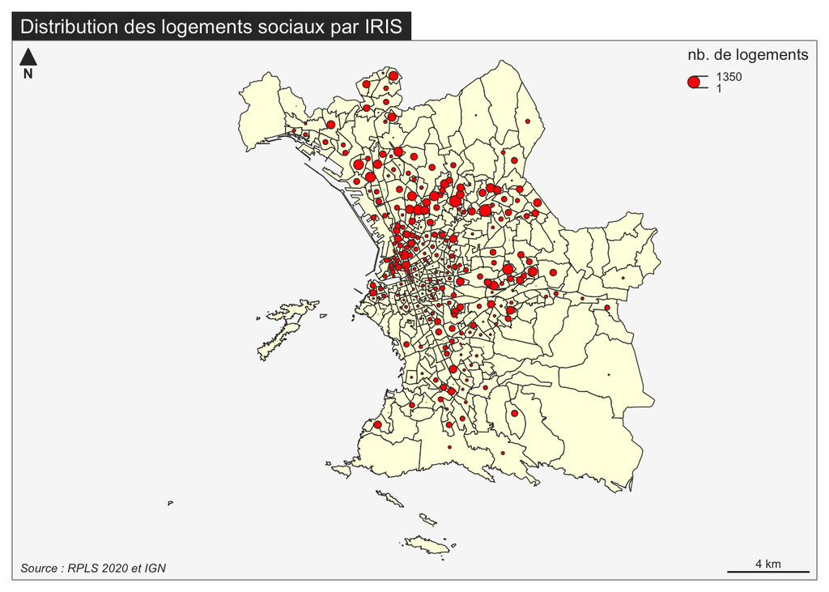

```r
mf_map(map_iris, type="base",col="lightyellow")
mf_map(map_iris_logt,
       type="prop",
       var="nb",
       col="red",
       inches=0.05,
       leg_title = "nb. de logements")
mf_layout(title = "Distribution des logements sociaux par IRIS",
          credits = "Source : RPLS 2020 et IGN",
          frame = TRUE,
          scale = TRUE)
```

## Agrégation par adresse

Nous revenons sur le **package sf (spatial features)** que nous avons déjà rencontré au moment de la création de cartes thématiques par IRIS ou communes à l’aide du package `mapsf`.

Ici le package sf va être utilisé pour cartographier non pas des zones mais des localisations ponctuelles. Il pourra être à nouveau couplé avec le logiciel de **cartogaphie statique** comme mapsf , afin par exemple de placer les localisations des logements sociaux au dessus du fonds de carte des IRIS ou communes.

Mais il pourra aussi servir de base à des **cartographies dynamiques** permettant de placer les points sur des réseaux de rue et plus généralement sur des “tuiles” cartographiques permettant d’effectur des zoom. On utilisera à cet effet d’autres packages comme `leaflet` ou sa version simplifiée `mapview`.

### Chargement des données

Nous chargeons le fichier des logements dans sa version géométrique c’est-à-dire comportant la position géométrique des unités spatiales. Nous le recodons et nous lui ajoutons les coordonnées X et Y des points de localisation.

```r
rpls<-readRDS("res/rpls_geom.RDS")

sel<-rpls %>% select(nbp = NBPIECE,
                     sup = SURFHAB,
                     anc = CONSTRUCT,
                     ene = DPEENERGIE,
                     fin = FINAN)

sel$fin <- case_when(sel$fin == "10" ~ "1.PLAI",
                     sel$fin == "11" ~ "1.PLAI",
                     sel$fin == "12" ~ "2.PLUS",
                     sel$fin == "13" ~ "2.PLUS",
                     sel$fin == "14" ~ "3.PLS",
                     sel$fin == "15" ~ "3.PLS",
                     sel$fin == "16" ~ "4.PLI",
                     sel$fin == "17" ~ "4.PLI",
                     sel$fin == "50" ~ "2.PLUS",
                     sel$fin == "51" ~ "2.PLUS",
                     sel$fin == "52" ~ "2.PLUS",
                     sel$fin == "53" ~ "2.PLUS",
                     sel$fin == "54" ~ "2.PLUS",
                     sel$fin == "55" ~ "2.PLUS",
                     .default = "0.Autre"
                     )



coo<-st_coordinates(sel)
sel$X<-coo[,1]
sel$Y<-coo[,2]


sel<-st_drop_geometry(sel)
```

### Agrégation par pseudo-adresse

On va considérer que chaque point (X,Y) correspond à une adresse - ce qui n’est pas toujours vrai - et reconstiuer un fichier agrégé par pseudo-adresse. On devrait obtenir ainsi une carte plus précise que la précédente.

```r
map_adr<-sel %>% st_drop_geometry %>%
              group_by(X,Y) %>%
              summarise(nb = n(),
                        nbp_moy = mean(nbp),
                        sup_moy = mean(sup),
                        anc_moy = mean(anc),
                        ene_min = min(ene),
                        fin_min = min(fin))

map_adr<-st_as_sf(map_adr,coords = c("X","Y"))
st_crs(map_adr)<-2154
head(map_adr)
```

```
Simple feature collection with 6 features and 6 fields
Geometry type: POINT
Dimension:     XY
Bounding box:  xmin: 887072.2 ymin: 6254194 xmax: 887107.4 ymax: 6254276
Projected CRS: RGF93 v1 / Lambert-93
# A tibble: 6 × 7
     nb nbp_moy sup_moy anc_moy ene_min fin_min           geometry
  <int>   <dbl>   <dbl>   <dbl> <chr>   <chr>          <POINT [m]>
1     1    5       83      1986 E       1.PLAI  (887072.2 6254276)
2     1    5       91      1986 E       1.PLAI  (887073.2 6254260)
3     1    6      102      1986 E       1.PLAI  (887074.2 6254243)
4     1    5       83      1986 E       1.PLAI  (887080.1 6254220)
5    13    2.69    58.2    1986 E       1.PLAI  (887092.7 6254207)
6     6    3.5     68.7    1986 E       1.PLAI  (887107.4 6254194)
```

### Carte par adresse

On procède à un test rapide de superposition sur la carte communale.

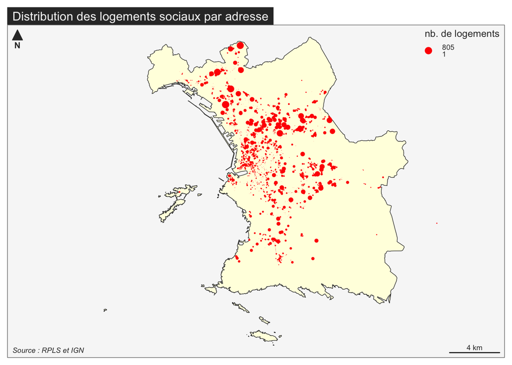

```r
map_com<-readRDS("res/map_com.RDS")
mf_map(map_com, type="base",col="lightyellow")
mf_map(map_adr,
       type="prop",
       var="nb",
       col="red",
       border = NA,
       inches=0.05,
       leg_title = "nb. de logements")
mf_layout(title = "Distribution des logements sociaux par adresse",
          credits = "Source : RPLS et IGN",
          frame = TRUE,
          scale = TRUE)
```

### Sauvegarde

On sauvegarde le fonds de carte des données par adresse

```r
saveRDS(map_adr,file = "res/logt_adr.RDS")
```